# GFtakehome_final

Gary Fowler

December 10, 2017

## Problem 1

Give precise definitions/descriptions for each of the following terms.

(A)the p-value of a test statistics TS for two sided hypothesis testing

The p-value is the probability that a standard normal would exceed sqrt(n)(Xbar - munot)/sigma

(B)the pooled estimator S2p of ??2 for two samples of sizes n and m from normal populations N(µ1, ??2) and N(µ2, ??2) respectively

$$S^2_p = \frac{(n-1)S^2_x + (m-1)S^2_y}{n + m - 2}$$

(C)the least squares estimator (LSE) of a regression parameters

$$B = \frac{\Sigma^n_{i=1}x_iY_i - \overline{x}\Sigma^n_{i=1}Y_i}{\Sigma^n_{i=1}x_i^2-n\overline{x}^2}$$
$$A = \overline{Y}-B\overline{x}$$
(D)the two sided %100(1 ??? ??) confidence level interval estimate of µ for a random sample of size n from a normal population with unknown ??

$$\mu \epsilon (\overline{x} - \frac{s}{\sqrt(n)}t_{a,n-1},\overline{x} + \frac{s}{\sqrt(n)}t_{a,n-1})$$

## Problem 2

Show that the estimator B of the parameter ?? in the simple linear regression model may be written as:

$$B=\frac{S_{xY}}{S_{xx}}$$

If we consider $S_{xY} = \Sigma^n_{i=1}(x_i-\overline{x})(y_i-\overline{y}) = \Sigma^n_{i=1} x_iY_i - n \overline{x}\overline{Y} = \frac{\Sigma^n_{i=1}x_iY_i-\Sigma^n_{i=1}x_i*\Sigma^n_{i=1}Y_i}{n}$

and if we consider $S_{xx} = \Sigma^n_{i=1}(x_i-\overline{x})^2 = \Sigma^n_{i=1}x_i^2 - n\overline{x}^2 = \frac{\Sigma^n_{i=1}x_i^2-(\Sigma^n_{i=1}x_i^2)}{n}$}$

now we must put these two as a fraction $\frac{\Sigma^n_{i=1}x_iY_i-\Sigma^n_{i=1}x_i*\Sigma^n_{i=1}Y_i}{n}$ / $\frac{\Sigma^n_{i=1}x_i^2-(\Sigma^n_{i=1}x_i^2)}{n}$

this equals
$$\frac{\Sigma^n_{i=1}x_iY_i-n\Sigma^n_{i=1}x_i*\Sigma^n_{i=1}Y_i}{\Sigma^n_{i=1}x_i^2-(\Sigma^n_{i=1}x_i^2)}$$

which is equivalent to B

Now we need to prove $SS_r =\frac{ S_{xx}S_{YY}-(S_{xY})^2}{S_xx}$

$SS_R = \Sigma(Y_i - A - B_{x_i})^2, A = (\frac{Y_i}{n}-B\overline{x}), B = \frac{S_{xY}}{S_{xx}}$

$SS_R = \Sigma(Y_i - \overline{Y} - B\overline{x}-Bx_i)^2 = \Sigma(Y_i - \overline{Y} - B(\overline{x}-x_i))^2$

Now if we square this quantity and perform some algebra we get:

$s_{YY} - 2S_{xY}B+B^2S_{xx} = s_{YY} - 2S_{xY}\frac{S_{xY}}{S_{xx}}+\frac{S_{xY}}{S_{xx}}^2S_{xx}=s_{YY} - 2\frac{S^2_{xY}}{S_{xx}}+\frac{S^2_{xY}}{S_{xx}}=s_{YY} - \frac{S^2_{xY}}{S_{xx}}=\frac{S_{xx}S_{YY}}{S_{xx}} - \frac{S^2_{xY}}{S_{xx}}=\frac{S_{xx}S_{YY}-S^2_{xY}}{S_{xx}}$

## Problem 3

Show that the estimator B of the parameter ?? in the simple linear regression model has the distribution

$$B = N(\beta,\sigma^2/S_{xx})$$

Since y_i is independent with $y_i = N(\beta x_in, \sigma^2)$ and x_i are constant:

$E(\beta) = \frac{1}{S_{xx}}ES_{xY} = \frac{1}{S_{xx}}\Sigma(x_i-\overline{x})EY_i = \frac{1}{S_{xx}}\beta\Sigma(x_i-\overline{x})x_i \frac{\beta}{S_{xx}}\Sigma(x_i^2-x_i\overline{x})=\frac{\beta}{S_{xx}}\Sigma(x_i^2-n\overline{x})= \frac{\beta}{S_{xx}}S_{xx}= \beta$

$Var(\beta) = \frac{1}{S^2_{xx}}Var(S_{xY}) = \frac{1}{S^2_{xx}}\Sigma(x_i-\overline{x})^2Var(y_i) = \frac{\sigma^2}{S_{xx}}$

Thus $B = N(\beta,\sigma^2/S_{xx})$

## Problem 4

It is known that the lifetimes tested at these locations are both normal with ??1 = 4000 km and ??2 = 6000 km respectively. What would be the conclusion if a %5 level of significance test for the mean lifetime of these two new tires is performed using the given data.

```r
sampleSize = 7
Avalues = c(61,58,62,62)
Bvalues = c(62,57,66)
alpha = .05

sigma1 = 4000
sigma2 = 6000

axbar = mean(Avalues)
bybar = mean(Bvalues)

hypnot = axbar - bybar #this is what we accept against
critical = sqrt((sigma1^2/4)+(sigma2^2/3))
critical
```

```
## [1] 4000
```

```r
z = (hypnot-alpha)/sqrt(alpha*(1-alpha)/sampleSize)
z*critical
```

```
## [1] -46939.55
```

```r
hypnot
```

```
## [1] -0.9166667
```

## Problem 5

Suppose X1, . . . , Xn are independent Poisson random variables each having mean ??.

1. Determine the maximum likelihood estimator of ??.

The function is: $f(x_1,...,x_n|\lambda) = \frac{e^{-\lambda}\lambda^{x_1}}{x_1!}...\frac{e^{-\lambda}\lambda^{x_n}}{x_n!} = \frac{e^{-n\lambda}\lambda^{ \Sigma_1^n x_i}}{x_1!...x_n!}$

$logf(x_1,...,x_n|\lambda)=-n\lambda + \Sigma^n_1x_ilog\lambda - logc$

c does not depend on lambda

$\frac{d}{d\lambda}logf(x_1,...,x_n|\lambda)=-n + \frac{\Sigma^n_1x_i}{\lambda}$

now we equate to 0 to obtain the estimator

$\hat\lambda=\frac{\Sigma^n_1x_i}{n}$

therefore:

$d(X_1,...,X_n)=\frac{\Sigma^n_1X_i}{n}$

2. The number of traffic accidents in a city in 10 randomly chosen non-rainy days in 2007 is as follows:

4, 0, 6, 5, 2, 1, 2, 0, 4, 3

What is the probability that a day in 2007 had two or fewer accidents in that city?

```r
data = c(4,0,6,5,2,1,2,0,4,3)
xbar = mean(data)
xbar
```

```
## [1] 2.7
```

```r
ppois(2,lambda=xbar) #we are looking for P(X <= 2)
```

```
## [1] 0.4936245
```

## Problem 6

Assume that the variance is ??^2 = 4 for a normal population, and consider the random data

5, 8.5, 12, 15, 7, 9, 7.5, 6.5, 10.5

from that population.

1. Construct a %95 confidence interval for µ.
2. Determine upper and lower %95 confidence interval estimates of µ.

Work the problem using the same sample data assuming this time that ?? is unknown.

```r
data = c(5,8.5,12,15,7,9,7.5,6.5,10.5)
xbar = mean(data)
xbar
```

```
## [1] 9
```

So our mu is 0, sigma is 2, n is 9, and xbar is 9

Then with a 95% confidence interval we find:

$(9-1.96\frac{\sigma}{3},9-1.96\frac{\sigma}{3}$

which is:

```r
xbar = 9
sigma = 2
n = 9

xbar - (1.96*sigma/sqrt(n))
```

```
## [1] 7.693333
```

```r
xbar + (1.96*sigma/sqrt(n))
```

```
## [1] 10.30667
```

So we are 95% confident that the true value lies between 7.69 and 10.31

1.645 * sigma/sqrt(n) = 1.097

The lower interval is: (-infinity,9+1.097) = (-inf,10.097)

The upper interval is: (9-1.097,inf) = (7.903,inf)

Now sigma is unknown

```r
data = c(5,8.5,12,15,7,9,7.5,6.5,10.5)
n = 9
xbar = mean(data)
xbar
```

```
## [1] 9
```

```r
s2 = var(data)
s2
```

```
## [1] 9.5
```

```r
s = sqrt(s2)
s
```

```
## [1] 3.082207
```

```r
s / sqrt(n)
```

```
## [1] 1.027402
```

Now we do a t.025,8

(9 - 2.306[3.082/3],9+2.306[3.082/3]) = (6.63,11.37)

Thus we are 95% certain that the true value is between 6.63 and 11.37

Lower

(-inf, 9 - 1.027(2.31)) = (-inf, 6.63)

Upper

(9 + 1.027(2.31) , inf) = (11.37, inf)

## Problem 7

x : 100 110 120 130 140 150 160 170

Y : 45 52 54 63 62 68 75 76

The Y corresponds to percent yield of a laboratory experiment and xi to temperature at which the experiment was run. Graph the scatter diagram, and find the estimated regression line.

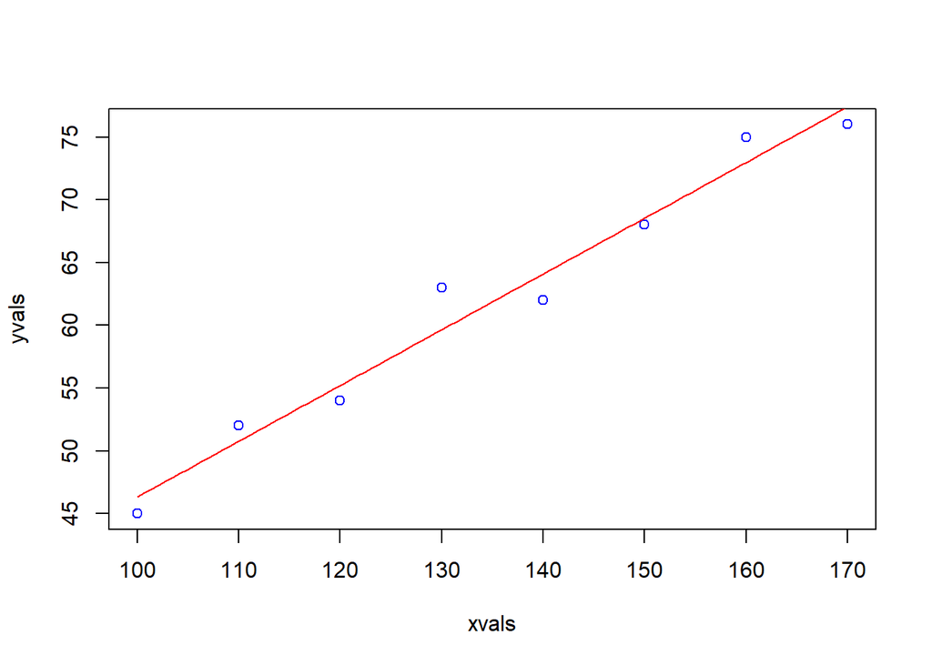

```r
xvals = c(100,110,120,130,140,150,160,170)
yvals = c(45,52,54,63,62,68,75,76)
points = cbind(xvals,yvals)
plot(points, col="blue")

s = function(r,m) sum((r-mean(r))*(m-mean(m)))
B = s(xvals, yvals)/s(xvals, xvals)
A = mean(yvals) - B*mean(xvals)
curve(A+B*x, add=T, col="red")
```